# Checking Xchrom EWAS results

Julia Romanowska

2022-06-13

# INTRO

## Read data

```r
# EWAS results
ewas_results_list <- readRDS(here("DATA", "XchromosomeResultsSexStratified.rds"))
class(ewas_results_list)
```

```
## [1] "list"
```

```r
names(ewas_results_list)
```

```
## [1] "Boys.1c"             "Boys.1d.bw"          "Boys.parents.1c"
## [4] "Boys.parents.1d.bw"  "Girls.1c"            "Girls.1d.bw"
## [7] "Girls.parents.1c"    "Girls.parents.1d.bw"
```

```r
ewas_results_list$Boys.1c
```

```
## # A tibble: 16,841 × 10
##    cpg_id     effect_size std_err  old_ps old_ps_adj_BH       ps ps_adj_BH CHR
##    <chr>            <dbl>   <dbl>   <dbl>         <dbl>    <dbl>     <dbl> <chr>
##  1 cg00920314      0.331   0.0559 3.37e-9     0.0000568 2.01e-10   3.39e-6 X
##  2 cg04516011      0.260   0.0452 9.15e-9     0.0000771 5.89e-10   4.96e-6 X
##  3 cg00243584      0.451   0.105  1.88e-5     0.106     2.31e- 6   1.30e-2 X
##  4 cg25153266      0.289   0.0731 7.90e-5     0.173     1.12e- 5   3.93e-2 X
##  5 cg12285371      0.158   0.0402 8.21e-5     0.173     1.17e- 5   3.93e-2 X
##  6 cg01806799      0.290   0.0804 3.03e-4     0.393     4.95e- 5   1.39e-1 X
##  7 cg24090346      0.176   0.0499 4.25e-4     0.426     7.20e- 5   1.73e-1 X
##  8 cg25863147      0.0771  0.0222 5.06e-4     0.426     8.75e- 5   1.84e-1 X
##  9 cg16328118      0.278   0.0832 8.40e-4     0.494     1.54e- 4   2.68e-1 X
## 10 cg12061216      0.460   0.138  8.65e-4     0.494     1.59e- 4   2.68e-1 X
## # … with 16,831 more rows, and 2 more variables: MAPINFO <dbl>, Strand <chr>
```

```r
# CpG data
cpg_info <- readRDS(here("DATA", "CpG_info_Xchrom_manifest.rds"))
```

## P-values

```r
ewas_results_tbl <- bind_rows(
  map(names(ewas_results_list), function(name){
    cur_res <- ewas_results_list[[name]]
    return(
      cur_res %>%
        tibble::add_column(group = name)
    )
  })
)

# add 'model' column with the name of the model as stated in manuscript!
ewas_results_tbl <- ewas_results_tbl %>%
  mutate(model = ifelse(
    str_detect(group, "[Boys|Girls|Both].1c"),
    yes = "Model 1",
    no = NA
  )) %>%
  mutate(model = ifelse(
    str_detect(group, "[Boys|Girls|Both].parents.1c"),
    yes = "Model 2",
    no = model
  )) %>%
  mutate(model = ifelse(
    str_detect(group, "[Boys|Girls|Both].1d.bw"),
    yes = "Model 3",
    no = model
  )) %>%
  mutate(model = ifelse(
    str_detect(group, "[Boys|Girls|Both].parents.1d.bw"),
    yes = "Model 4",
    no = model
  )) %>%
  mutate(group = word(group, 1, 1, sep = "\\."))
ewas_results_tbl
```

```
## # A tibble: 134,728 × 12
##    cpg_id     effect_size std_err  old_ps old_ps_adj_BH       ps ps_adj_BH CHR
##    <chr>            <dbl>   <dbl>   <dbl>         <dbl>    <dbl>     <dbl> <chr>
##  1 cg00920314      0.331   0.0559 3.37e-9     0.0000568 2.01e-10   3.39e-6 X
##  2 cg04516011      0.260   0.0452 9.15e-9     0.0000771 5.89e-10   4.96e-6 X
##  3 cg00243584      0.451   0.105  1.88e-5     0.106     2.31e- 6   1.30e-2 X
##  4 cg25153266      0.289   0.0731 7.90e-5     0.173     1.12e- 5   3.93e-2 X
##  5 cg12285371      0.158   0.0402 8.21e-5     0.173     1.17e- 5   3.93e-2 X
##  6 cg01806799      0.290   0.0804 3.03e-4     0.393     4.95e- 5   1.39e-1 X
##  7 cg24090346      0.176   0.0499 4.25e-4     0.426     7.20e- 5   1.73e-1 X
##  8 cg25863147      0.0771  0.0222 5.06e-4     0.426     8.75e- 5   1.84e-1 X
##  9 cg16328118      0.278   0.0832 8.40e-4     0.494     1.54e- 4   2.68e-1 X
## 10 cg12061216      0.460   0.138  8.65e-4     0.494     1.59e- 4   2.68e-1 X
## # … with 134,718 more rows, and 4 more variables: MAPINFO <dbl>, Strand <chr>,
## #   group <chr>, model <chr>
```

### after BACON adjustment

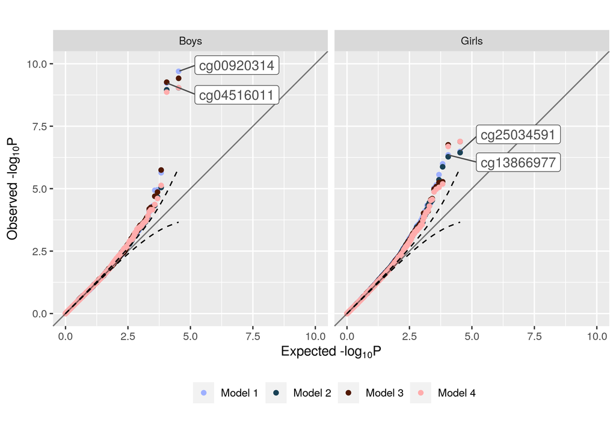

```r
all_pvals <- ewas_results_tbl$ps
names(all_pvals) <- paste0(ewas_results_tbl$group, ewas_results_tbl$model)
pvals_qqplot <- create_df_qq(all_pvals) %>%
  dplyr::select(-group) %>%
  bind_cols(
    ewas_results_tbl %>%
      arrange(group, model, ps) %>%
      dplyr::select(group, model, cpg_id)
  )

log10Pe <- expression(paste("Expected -log"[10], plain(P)))
log10Po <- expression(paste("Observed -log"[10], plain(P)))
max.lims <- range(c(pvals_qqplot$observed, pvals_qqplot$expected)) + 0.5

(qqplots_both_all_models_afterbacon <- ggplot(pvals_qqplot) +
  geom_point(aes(expected, observed, color = model)) +
  scale_color_scico_d(palette = "berlin", name = "") +
  facet_wrap(facets = vars(group)) +
  geom_abline(intercept = 0, slope = 1, alpha = 0.5) +
  geom_line(aes(expected, cupper), linetype = 2) +
  geom_line(aes(expected, clower), linetype = 2) +
  # showing labels only for the two most signif.CpGs - these are the
    #  same across models for girls-only and boys-only groups
  geom_label_repel(
    aes(expected, observed, label = cpg_id),
    color = "grey30",
    data = pvals_qqplot %>%
      filter(model == "Model 1") %>%
      group_by(group, model) %>%
      slice(1:2),
    xlim = c(5, NA),
    force = 100#,
    # max.iter = 100000
  ) +
  xlab(log10Pe) +
  ylab(log10Po) +
  ylim(0, round(max.lims[2])) +
  xlim(0, round(max.lims[2])) +
  coord_fixed(clip = FALSE) +
  theme(legend.position = "bottom"))
```

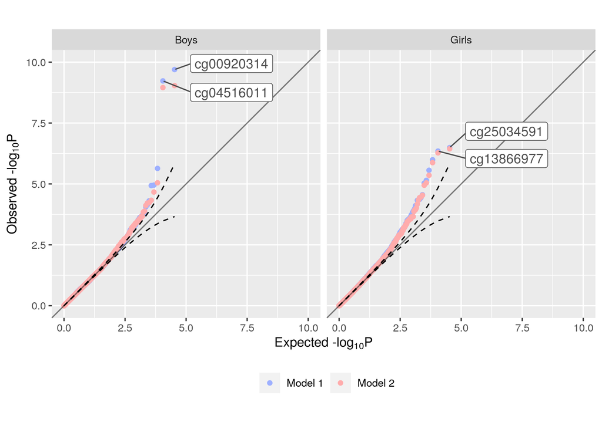

```r
(qqplots_both_models1_2_afterbacon <- ggplot(
  pvals_qqplot %>% filter(model %in% c("Model 1", "Model 2"))
  ) +
  geom_point(aes(expected, observed, color = model)) +
  facet_grid(cols = vars(group)) +
  geom_abline(intercept = 0, slope = 1, alpha = 0.5) +
  geom_line(aes(expected, cupper), linetype = 2) +
  geom_line(aes(expected, clower), linetype = 2) +
  scale_color_scico_d(palette = "berlin", name = "") +
  # showing labels only for the two most signif.CpGs - these are the
    #  same across models for girls-only and boys-only groups
  geom_label_repel(
    aes(expected, observed, label = cpg_id),
    color = "grey30",
    data = pvals_qqplot %>%
      filter(model == "Model 1") %>%
      group_by(group, model) %>%
      slice(1:2),
    xlim = c(5, NA),
    force = 100#,
    # max.iter = 100000
  ) +
  xlab(log10Pe) +
  ylab(log10Po) +
  ylim(0, round(max.lims[2])) +
  xlim(0, round(max.lims[2])) +
  coord_fixed(clip = FALSE) +
  theme(legend.position = "bottom"))
```

### before BACON adjustment

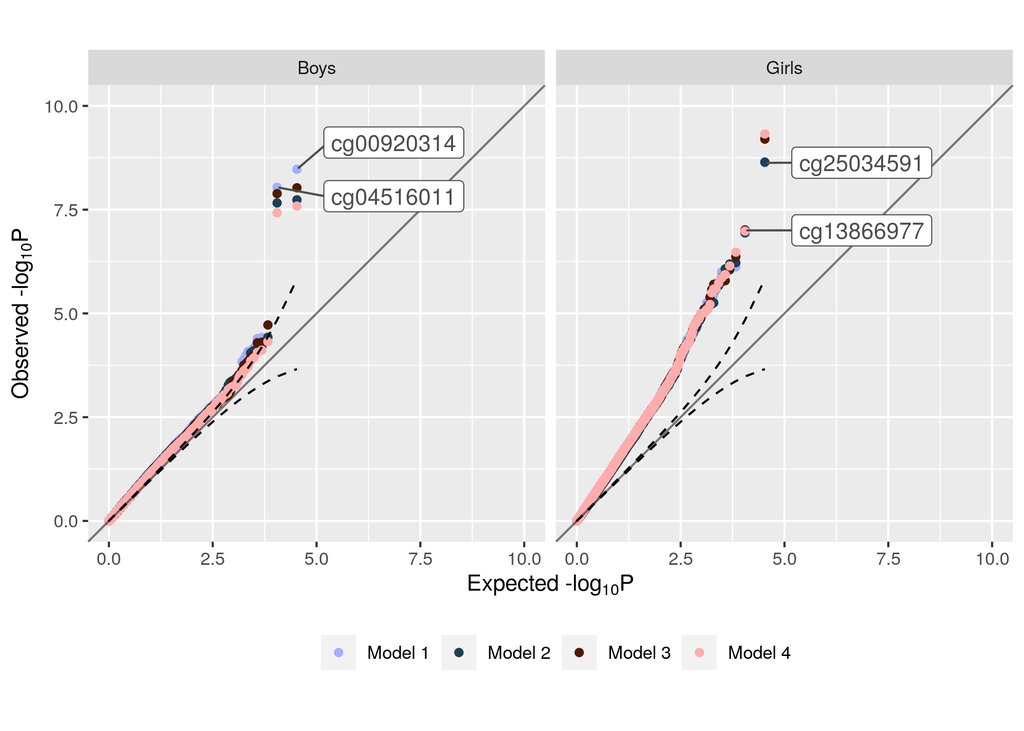

```r
all_pvals_b4 <- ewas_results_tbl$old_ps
names(all_pvals_b4) <- paste0(ewas_results_tbl$group, ewas_results_tbl$model)
pvals_qqplot_b4 <- create_df_qq(all_pvals_b4) %>%
  dplyr::select(-group) %>%
  bind_cols(
    ewas_results_tbl %>%
      arrange(group, model, ps) %>%
      dplyr::select(group, model, cpg_id)
  )

max.lims_b4 <- range(c(pvals_qqplot_b4$observed, pvals_qqplot_b4$expected)) + 0.5

(qqplots_both_all_models_beforebacon <- ggplot(pvals_qqplot_b4) +
  geom_point(aes(expected, observed, color = model)) +
  facet_wrap(facets = vars(group)) +
  geom_abline(intercept = 0, slope = 1, alpha = 0.5) +
  geom_line(aes(expected, cupper), linetype = 2) +
  geom_line(aes(expected, clower), linetype = 2) +
  scale_color_scico_d(palette = "berlin", name = "") +
  # showing labels only for the two most signif.CpGs - these are the
    #  same across models for girls-only and boys-only groups
  geom_label_repel(
    aes(expected, observed, label = cpg_id),
    color = "grey30",
    data = pvals_qqplot_b4 %>%
      filter(model == "Model 1") %>%
      group_by(group, model) %>%
      slice(1:2),
    xlim = c(5, NA),
    force = 100#,
    # max.iter = 100000
  ) +
  xlab(log10Pe) +
  ylab(log10Po) +
  ylim(0, round(max.lims_b4[2])) +
  xlim(0, round(max.lims_b4[2])) +
  coord_fixed(clip = FALSE) +
  theme(legend.position = "bottom"))
```

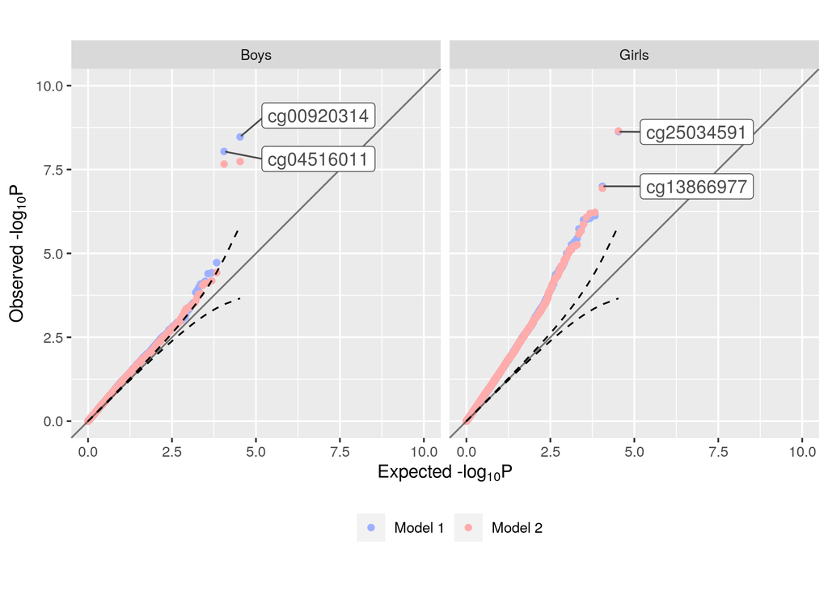

```r
(qqplots_both_models1_2_beforebacon <- ggplot(
  pvals_qqplot_b4 %>% filter(model %in% c("Model 1", "Model 2"))
  ) +
  geom_point(aes(expected, observed, color = model)) +
  facet_grid(cols = vars(group)) +
  geom_abline(intercept = 0, slope = 1, alpha = 0.5) +
  geom_line(aes(expected, cupper), linetype = 2) +
  geom_line(aes(expected, clower), linetype = 2) +
  scale_color_scico_d(palette = "berlin", name = "") +
  # showing labels only for the two most signif.CpGs - these are the
    #  same across models for girls-only and boys-only groups
  geom_label_repel(
    aes(expected, observed, label = cpg_id),
    color = "grey30",
    data = pvals_qqplot_b4 %>%
      filter(model == "Model 1") %>%
      group_by(group, model) %>%
      slice(1:2),
    xlim = c(5, NA),
    force = 100#,
    # max.iter = 100000
  ) +
  xlab(log10Pe) +
  ylab(log10Po) +
  ylim(0, round(max.lims_b4[2])) +
  xlim(0, round(max.lims_b4[2])) +
  coord_fixed(clip = FALSE) +
  theme(legend.position = "bottom"))
```

```r
# all models
((qqplots_both_all_models_beforebacon +
    labs(title = "A) p-values before applying BACON"))
  / (qqplots_both_all_models_afterbacon +
      labs(title = "B) p-values after applying BACON"))
 ) +
  plot_layout(guides = "collect") &
  theme(legend.position = "bottom")

ggsave(here("FIGURES", "qqplots_before-after_BACON_all_models.png"),
       width = 6, height = 7)

# models 1-2
((qqplots_both_models1_2_beforebacon +
    labs(title = "A) p-values before applying BACON"))
  / (qqplots_both_models1_2_afterbacon +
      labs(title = "B) p-values after applying BACON"))
 ) +
  plot_layout(guides = "collect") &
  theme(legend.position = "bottom")

ggsave(here("FIGURES", "qqplots_before-after_BACON_models1-2.png"),
       width = 6, height = 7)
```

## Volcano plots

Checking the overall distibution of effect sizes for boys-only and girls-only analyses.

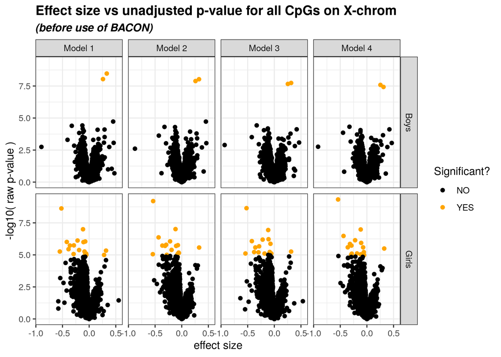

```r
ewas_results_tbl <- ewas_results_tbl %>%
  mutate(
    ps_adj_BH = stats::p.adjust(ps, method = "BH"),
    old_signif = (old_ps_adj_BH < signif_pval_thresh),
    signif = (ps_adj_BH < signif_pval_thresh)
  )

ggplot(ewas_results_tbl, aes(effect_size, -log10(old_ps))) +
  geom_point(aes(col = old_signif)) +
  scale_color_manual(
    "Significant?",
    values = c("black", "orange"),
    labels = c("NO", "YES")
  ) +
  facet_grid(rows = vars(group), cols = vars(model)) +
  xlab("effect size") +
  ylab("-log10( raw p-value )") +
  theme_bw() +
  labs(
    title = "Effect size vs unadjusted p-value for all CpGs on X-chrom",
    subtitle = "(before use of BACON)",
  ) +
  theme(
    plot.title = element_text(face = "bold"),
    plot.subtitle = element_text(face = "bold.italic")
  )
```

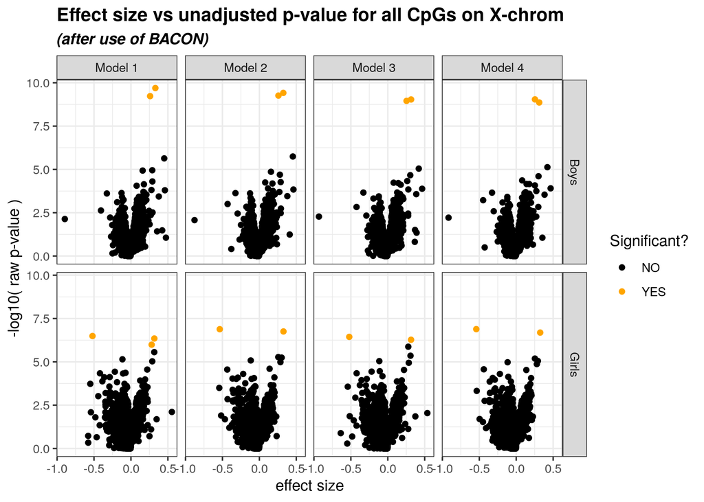

```r
#ggsave(here("FIGURES", "volcano_plot_before_BACON.png"))

ggplot(ewas_results_tbl, aes(effect_size, -log10(ps))) +
  geom_point(aes(col = signif)) +
  scale_color_manual(
    "Significant?",
    values = c("black", "orange"),
    labels = c("NO", "YES")
  ) +
  facet_grid(rows = vars(group), cols = vars(model)) +
  xlab("effect size") +
  ylab("-log10( raw p-value )") +
  theme_bw() +
  labs(
    title = "Effect size vs unadjusted p-value for all CpGs on X-chrom",
    subtitle = "(after use of BACON)"
  ) +
  theme(
    plot.title = element_text(face = "bold"),
    plot.subtitle = element_text(face = "bold.italic")
  )
```

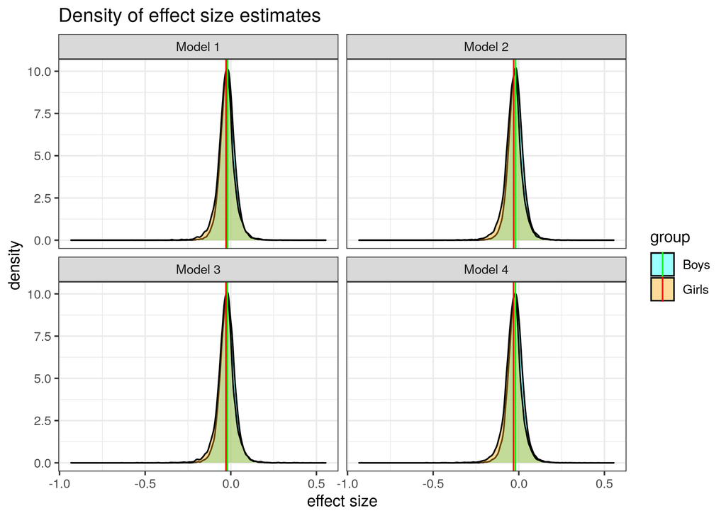

```r
#ggsave(here("FIGURES", "volcano_plot_after_BACON.png"))

median_effect_size <- ewas_results_tbl %>%
  group_by(group, model) %>%
  summarise(
    med_eff_size = median(effect_size),
    sd_eff_size = sd(effect_size),
    min_eff_size = min(effect_size),
    max_eff_size = max(effect_size)
  )

ggplot(ewas_results_tbl, aes(effect_size)) +
  geom_density(aes(fill = group), alpha = 0.4) +
  facet_wrap(facets = vars(model)) +
  geom_vline(
    data = median_effect_size,
    aes(xintercept = med_eff_size, col = group)
  ) +
  scale_fill_manual(values = c("cyan", "orange")) +
  scale_color_manual(values = c("green", "red")) +
  theme_bw() +
  xlab("effect size") +
  labs(title = "Density of effect size estimates")
```

```r
ggsave(here("FIGURES", "density_effect_size_compare.png"))
```

```r
volcano_pl_m1_b4b <- ewas_results_tbl %>%
  filter(model == "Model 1") %>%
  ggplot(aes(effect_size, -log10(old_ps))) +
  geom_point(aes(col = old_signif), size = 0.8) +
  scale_color_manual(
    "Significant?",
    values = c("black", "orange"),
    labels = c("NO", "YES")
  ) +
  facet_grid(rows = vars(group)) +
  xlab("effect size") +
  ylab("-log10( raw p-value )") +
  theme_bw() +
  labs(
    # title = "Effect size vs unadjusted p-value for all CpGs on X-chrom",
    title = "A) before BACON adjustment",
  ) +
  theme(
    plot.title = element_text(face = "bold"),
    plot.subtitle = element_text(face = "bold.italic"),
    plot.title.position = "plot"
  )

volcano_pl_m1_a4b <- ewas_results_tbl %>%
  filter(model == "Model 1") %>%
  ggplot(aes(effect_size, -log10(ps))) +
  geom_point(aes(col = signif), size = 0.8) +
  scale_color_manual(
    "Significant?",
    values = c("black", "orange"),
    labels = c("NO", "YES")
  ) +
  facet_grid(rows = vars(group)) +
  xlab("effect size") +
  ylab("-log10( raw p-value )") +
  theme_bw() +
  labs(
    # title = "Effect size vs unadjusted p-value for all CpGs on X-chrom",
    title = "B) after BACON adjustment"
  ) +
  theme(
    plot.title = element_text(face = "bold"),
    plot.subtitle = element_text(face = "bold.italic"),
    plot.title.position = "plot"
  )

(volcano_pl_m1_b4b + volcano_pl_m1_a4b) + plot_layout(guides = "collect")
ggsave(
  here("FIGURES", "volcano_plots_m1.png"),
  width = 10,
  height = 6
)
```

```r
volcano_pl_b4b <- ggplot(ewas_results_tbl, aes(effect_size, -log10(old_ps))) +
  geom_point(aes(col = old_signif), size = 0.8) +
  scale_color_manual(
    "Significant?",
    values = c("black", "orange"),
    labels = c("NO", "YES")
  ) +
  facet_grid(rows = vars(group), cols = vars(model)) +
  xlab("effect size") +
  ylab("-log10( raw p-value )") +
  theme_bw() +
  labs(
    # title = "Effect size vs unadjusted p-value for all CpGs on X-chrom",
    title = "A) before BACON adjustment",
  ) +
  theme(
    plot.title = element_text(face = "bold"),
    plot.subtitle = element_text(face = "bold.italic")
  )

volcano_pl_a4b <- ggplot(ewas_results_tbl, aes(effect_size, -log10(ps))) +
  geom_point(aes(col = signif), size = 0.8) +
  scale_color_manual(
    "Significant?",
    values = c("black", "orange"),
    labels = c("NO", "YES")
  ) +
  facet_grid(rows = vars(group), cols = vars(model)) +
  xlab("effect size") +
  ylab("-log10( raw p-value )") +
  theme_bw() +
  labs(
    # title = "Effect size vs unadjusted p-value for all CpGs on X-chrom",
    title = "B) after BACON adjustment"
  ) +
  theme(
    plot.title = element_text(face = "bold"),
    plot.subtitle = element_text(face = "bold.italic")
  )

(volcano_pl_b4b / volcano_pl_a4b) + plot_layout(guides = "collect")
ggsave(
  here("FIGURES", "volcano_plots_all.png"),
  width = 8,
  height = 6
)
```

## Significant results

Which are common among the most significant?

```r
signif_results_girls <- map(
  signif_results_list[
    str_subset(names(signif_results_list), fixed("Girls."))
  ],
  function(x){
    return(x$cpg_id)
})

signif_all_models_girls <- Reduce(
  f = union,
  signif_results_girls
)

signif_common_all_models_girls <- Reduce(
  f = intersect,
  x = signif_results_girls
)
signif_common_1_2_models_girls <- Reduce(
  f = intersect,
  x = signif_results_girls[c(1,3)]
)
```

### How many significant?

```r
no_signif_per_model <- map_int(signif_results_list, nrow)
knitr::kable(
  as_tibble(no_signif_per_model, rownames = "model"),
  col.names = c("model", "# signif. CpGs")
)
```

| model | # signif. CpGs |
| --- | --- |
| Boys.1c | 2 |
| Boys.1d.bw | 2 |
| Boys.parents.1c | 2 |
| Boys.parents.1d.bw | 2 |
| Girls.1c | 3 |
| Girls.1d.bw | 3 |
| Girls.parents.1c | 2 |
| Girls.parents.1d.bw | 2 |

```r
upsetr_signif_list <- map(signif_results_list, function(x){
  cur_res <- as.factor(x$cpg_id)
  return(cur_res)
})
# this re-ordering is just for producing nice figure
names(upsetr_signif_list) <- c(
  paste0("Boys_model", c(1, 3, 2, 4)),
  paste0("Girls_model", c(1, 3, 2, 4))
)
upsetr_signif_list <- upsetr_signif_list[
  c(paste0("Boys_model", 1:4),
  paste0("Girls_model", 1:4))
]
png(filename = here("FIGURES", "upset_all_models_number_signif_cpg.png"),
    width = 9, height = 6, units = "in", res = 100)
upset(
  fromList(upsetr_signif_list),
  order.by = "freq",
  nsets = length(upsetr_signif_list),
  text.scale = 1.5
)
dev.off()
```

## Fetching annotations

```r
regul_regs_file <- here("DATA", "regulatory_regions.rds")

if(!file.exists(regul_regs_file)){
  ensembl_reg <- useEnsembl("regulation",
    dataset = "hsapiens_regulatory_feature",
    GRCh = 37)

  my_attribs <- c(
    "regulatory_stable_id",
    "chromosome_name",
    "chromosome_start",
    "chromosome_end",
    "feature_type_name",
    "feature_type_description",
    "so_accession"
  )
  my_filters <- c(
    "chromosome_name",
    "start", "end"
  )

  regulatory_regs <- map(signif_results_list, function(x){
    cur_data <- x %>%
      mutate(
        end = MAPINFO + 1
      ) %>%
      dplyr::select(CHR, MAPINFO, end)
    colnames(cur_data) <- my_filters
    out <- grabRegulRegions(
      cur_data, ensembl_reg, my_attribs, my_filters, asGRanges = TRUE
    )
  })
  saveRDS(regulatory_regs, file = regul_regs_file)
} else {
  regulatory_regs <- readRDS(regul_regs_file)
}
```

```r
genes_regs_file <- here("DATA", "genes_regions.rds")

if(!file.exists(genes_regs_file)){
  ensembl_genes <- useEnsembl("genes",
    dataset = "hsapiens_gene_ensembl",
    GRCh = 37)

  my_attribs <- c(
    "ensembl_gene_id",
    "description",
    "external_gene_name",
    "start_position", "end_position"
  )
  my_filters <- c(
    "chromosome_name",
    "start", "end"
  )

  genes_regs <- map(signif_results_list, function(x){
    cur_data <- x %>%
      mutate(
        end = MAPINFO + 1
      ) %>%
      dplyr::select(CHR, MAPINFO, end)
    colnames(cur_data) <- my_filters
    out <- grabRegulRegions(
      positions = cur_data,
      mart = ensembl_genes,
      attribs = my_attribs,
      filters = my_filters,
      asGRanges = TRUE
    )
    return(out)
  })
  saveRDS(genes_regs, file = genes_regs_file)
} else {
  genes_regs <- readRDS(genes_regs_file)
}
```

### Plot these annotations

```r
txdb <- TxDb.Hsapiens.UCSC.hg19.knownGene::TxDb.Hsapiens.UCSC.hg19.knownGene
all.genes <- karyoploteR::makeGenesDataFromTxDb(
  txdb, plot.transcripts = FALSE, plot.transcripts.structure = FALSE)$genes
all.genes.tbl <- as_tibble(as.data.frame(all.genes))

walk(names(ewas_results_list), function(x){
  cur_data_all <- ewas_results_list[[x]]
  cur_data_signif <- signif_results_list[[x]]
  cur_genes_regs <- genes_regs[[x]]
  cur_reg_regs <- regulatory_regs[[x]]
  cur_y_lim <- range(-log10(cur_data_all$ps_adj_BH))

  png(filename = here("FIGURES", paste0("signif_cpg_annot_model-", x, ".png")),
      width = 800, height = 480, pointsize = 16)
  kp <- karyoploteR::plotKaryotype(
    chromosomes = paste0("chr", chr),
    plot.type = 2
  )
  # plotting gene density
  karyoploteR::kpPlotDensity(
    kp, all.genes,
    data.panel = 1, r0 = 0, r1 = 0.4
  )
  karyoploteR::kpAddLabels(
    kp, labels = "gene density",
    data.panel = 1, r0 = 0, r1 = 0.3,
    label.margin = -0.02
  )
  # plotting CpG p-values
  karyoploteR::kpPoints(
    kp,
    x = cur_data_signif$MAPINFO,
    y = -log10(cur_data_signif$ps_adj_BH),
    chr = paste0("chr", chr),
    data.panel = 1, cex = 1.5,
    col = "cyan",
    r0 = 0.5, r1 = 1,
    ymin = 0,
    ymax = cur_y_lim[2]
  )
  karyoploteR::kpPoints(
    kp,
    x = cur_data_all$MAPINFO,
    y = -log10(cur_data_all$ps_adj_BH),
    chr = paste0("chr", chr),
    data.panel = 1,
    r0 = 0.5, r1 = 1,
    ymin = 0,
    ymax = cur_y_lim[2]
  )
  karyoploteR::kpAxis(
    kp, data.panel = 1,
    r0 = 0.5, r1 = 1,
    ymin = 0,
    ymax = cur_y_lim[2]
  )
  karyoploteR::kpAddLabels(
    kp, labels = "-log10(FDR)",
    srt = 90, data.panel = 1,
    r0 = 1, r1 = 0.9,
    label.margin = 0.07
  )

  if(length(cur_reg_regs) != 0){
    # plotting regulatory regs
    karyoploteR::kpDataBackground(
      kp, data.panel = 2,
      r0 = 0.55, r1 = 0.8,
      color = "#D3E1FF"
    )
    karyoploteR::kpPlotRegions(
      kp, data = cur_reg_regs,
      data.panel = 2, r0 = 0.55, r1 = 0.8,
      col = "navyblue",
      border = "navyblue"
    )
    karyoploteR::kpPlotMarkers(
      kp, data = cur_reg_regs,
      labels = cur_reg_regs$feature_type_name,
      data.panel = 2, r0 = 0, r1 = 1,
      text.orientation = "horizontal",
      label.dist = 0.01,
      label.margin = 5,
      label.color = "navyblue",
      line.color = "navyblue",
      ignore.chromosome.ends = TRUE
    )
    karyoploteR::kpAddLabels(
      kp, labels = "regulatory\n regions",
      data.panel = 2, r0 = 0.6, r1 = 1,
      col = "navyblue"
    )
  }
  # plotting genes
  karyoploteR::kpPlotRegions(
    kp, data = cur_genes_regs,
    data.panel = 2, r0 = 0, r1 = 0.2
  )
  karyoploteR::kpPlotMarkers(
    kp, data = cur_genes_regs,
    labels = cur_genes_regs$external_gene_name,
    data.panel = 2, r0 = 0, r1 = 0.4,
    text.orientation = "horizontal",
    label.dist = 0.01,
    label.margin = 5,
    ignore.chromosome.ends = TRUE
  )
  karyoploteR::kpAddLabels(
    kp, labels = "genes",
    data.panel = 2, r0 = 0.2, r1 = 0.45
  )
  # title
  title(main = paste0(
    stringr::word(x, 1, 1, sep = stringr::fixed(".")),
    ", model ",
    match(
      stringr::word(x, 2, -1, sep = stringr::fixed(".")), all_model_names
    )
  ))
  dev.off()
})
```

### How many overlap?

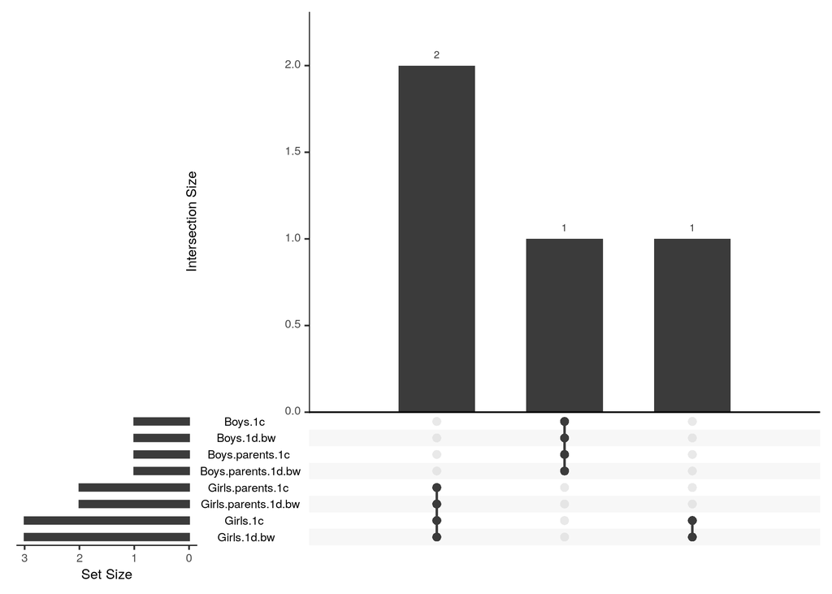

Overlap between the models in terms of which genes are covered by the significant CpGs

```r
upsetr_genes_list <- map(genes_regs, function(cur_genes){
  return(as.factor(cur_genes$external_gene_name))
})
upset(fromList(upsetr_genes_list), nsets = length(upsetr_genes_list),
      order.by = "freq")
```

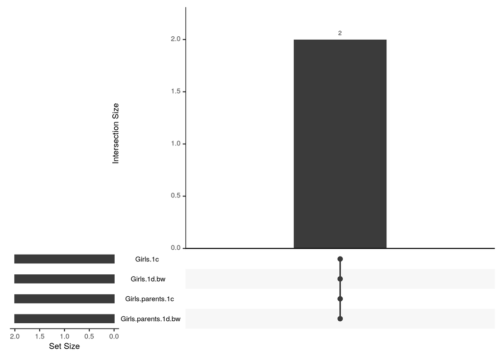

Overlap between the models in terms of which regulatory regions are covered by the significant CpGs

```r
upsetr_regul_list <- map(regulatory_regs, function(cur_regul){
  return(as.factor(cur_regul$regulatory_stable_id))
})
upset(fromList(upsetr_regul_list), nsets = length(upsetr_regul_list),
      order.by = "freq")
```

### Nice tables

Summing up the results

```r
# tidy data
signif_results_gen_location <- map(
  names(signif_results_list),
  function(name){
    cur_data <- signif_results_list[[name]]
    cur_regul_regs <- as_tibble(regulatory_regs[[name]])
    cur_genes_regs <- as_tibble(genes_regs[[name]])

    # adding the information on regulatory regions, if any
    empty_tbl <- tibble(region_ID = NA,
            region_type = NA,
            region_position = NA)
    out <- bind_cols(
      cur_data,
      empty_tbl
    )
    if(nrow(cur_regul_regs) != 0){
      cur_regul_regs <- cur_regul_regs %>%
        distinct()
      out <- map(seq_len(nrow(cur_data)), function(row){
        cur_row <- cur_data[row,]
        tmp_regul_regs <- cur_regul_regs %>%
          filter(
              cur_row$MAPINFO <= end &
              cur_row$MAPINFO >= start
            ) %>%
          mutate(region_position = paste0(
            "chrX:", format(start, big.mark = ","),
            "-", format(end, big.mark = ","))) %>%
          dplyr::select(
            region_ID = regulatory_stable_id,
            region_type = feature_type_name,
            region_position
          )

        if(nrow(tmp_regul_regs) == 0){
          tmp_regul_regs <- empty_tbl
        }
        return(bind_cols(cur_row, tmp_regul_regs))
      }) %>%
        bind_rows()
    }
    # adding the information on genes regions, if any
    if(nrow(cur_genes_regs) != 0){
      cur_genes_regs <- cur_genes_regs %>%
        distinct()
      out <- map(seq_len(nrow(out)), function(row){
        cur_row <- out[row,]
        tmp_genes_regs <- cur_genes_regs %>%
          filter(
              cur_row$MAPINFO <= end &
              cur_row$MAPINFO >= start
            ) %>%
          mutate(gene_position = paste0(
            "chrX:", format(start, big.mark = ","),
            "-", format(end, big.mark = ","))) %>%
          dplyr::select(
            gene_ID = ensembl_gene_id,
            gene_descr = description,
            gene_name = external_gene_name,
            gene_position
          )

        if(nrow(tmp_genes_regs) == 0){
          tmp_genes_regs <- tibble(
            gene_ID = NA,
            gene_descr = NA,
            gene_name = NA,
            gene_position = NA
          )
        }
        return(bind_cols(cur_row, tmp_genes_regs))
      }) %>%
        bind_rows()
    }
    out <- out %>%
      tibble::add_column(group = name)
    return(out)
  }) %>%
  bind_rows() %>%
  mutate(model = ifelse(
    str_detect(group, "[Boys|Girls].1c"),
    yes = "Model 1",
    no = NA
  )) %>%
  mutate(model = ifelse(
    str_detect(group, "[Boys|Girls].parents.1c"),
    yes = "Model 2",
    no = model
  )) %>%
  mutate(model = ifelse(
    str_detect(group, "[Boys|Girls].1d.bw"),
    yes = "Model 3",
    no = model
  )) %>%
  mutate(model = ifelse(
    str_detect(group, "[Boys|Girls].parents.1d.bw"),
    yes = "Model 4",
    no = model
  )) %>%
  mutate(group = stringr::word(group, 1, 1, sep = stringr::fixed("."))) %>%
  arrange(group, model, MAPINFO) %>%
  group_by(group, model)

# using gt package to make it nice
signif_results_gen_location_gt <- gt(
    signif_results_gen_location %>%
      dplyr::select(!c(old_ps, old_ps_adj_BH, CHR, std_err, ps))
  ) %>%
  tab_header(
    title = md("**Most significant findings (FDR < 0.05)**"),
    subtitle = md("_(grouped by sex and model)_")
  ) %>%
  tab_spanner(
    label = md("**CpG info**"),
    columns = c(cpg_id, MAPINFO)
  ) %>%
  tab_spanner(
    label = md("**EWAS results**"),
    columns = c(effect_size, ps_adj_BH)
  ) %>%
  tab_spanner(
    label = md("**Regulatory regions**"),
    id = "reg_regions",
    columns = c(region_ID, region_type, region_position)
  ) %>%
  tab_spanner(
    label = md("**Genes**"),
    id = "genes",
    columns = c(gene_ID, gene_descr, gene_name, gene_position)
  ) %>%
  cols_label(
    cpg_id = "CpG ID",
    MAPINFO = "Position (chrX)",
    effect_size = "Effect size",
    ps_adj_BH = "FDR",
    region_ID = "Ensembl ID",
    region_type = "Region type",
    region_position = "Position",
    gene_ID = "Ensembl ID",
    gene_descr = "Description",
    gene_name = "Gene ID",
    gene_position = "Position"
  ) %>%
  tab_options(
    row_group.background.color = "#E6C2AA",
    row_group.font.weight = "bold",
    column_labels.background.color = "#F6DA91"
  ) %>%
  fmt_scientific(
    columns = c(ps_adj_BH)
  ) %>%
  fmt_number(
    columns = c(effect_size),
    decimals = 2
  ) %>%
  fmt_number(
    columns = MAPINFO,
    use_seps = TRUE,
    decimals = 0
  ) %>%
  tab_style(
    style = list(
      cell_text(style = "italic")
      ),
    locations = cells_body(
      columns = gene_descr,
      rows = !is.na(gene_descr)
    )
  ) %>%
  tab_style(
    style = list(
      cell_text(weight = "bold")
      ),
    locations = cells_body(
      columns = cpg_id
    )
  ) %>%
  tab_style(
    style = list(
      cell_text(align = "center")
      ),
    locations = cells_row_groups()
  ) %>%
  tab_style(
    style = list(
      cell_text(align = "center")
      ),
    locations = cells_body(
      rows = is.na(everything())
    )
  ) %>%
  tab_style(
    style = list(
      cell_borders(
        sides = "right"
      )
    ),
    locations = cells_body(
      columns = c(ps_adj_BH, region_position)
    )
  ) %>%
  data_color(
    columns = effect_size,
    colors = scales::col_numeric(
      palette = scico(5, palette = 'roma'),
      domain = range(signif_results_gen_location$effect_size)
    )
  ) %>%
  tab_footnote(
    footnote = "Color shading reflects the magnitude and the sign of the estimated effect - from dark red (strong negative effect), through beige (weak negative effect), and dark blue (strong positive effect).",
    locations = cells_column_labels(
      columns = effect_size
    )
  ) %>%
  tab_footnote(
    footnote = "NA = Not applicable",
    locations = cells_column_spanners(
      spanners = c("reg_regions", "genes")
    )
  ) %>%
  tab_footnote(
    footnote = "genome build GRCh 37",
    locations = cells_column_labels(
      columns = c("gene_position", "MAPINFO", "region_position")
    )
  )
# signif_results_gen_location_gt
```

## Check against gaphunter results

### Girls only

```r
gaphunter_res_girls <- readRDS(
  here("DATA", "gaphunting_res_girls_TXT.rds")
)
names(gaphunter_res_girls)
```

```
## [1] "proberesults"  "sampleresults" "algorithm"
```

There were 91 possibly multimodal CpGs found.

Were there any gap-CpGs in the results?

```r
gap_cpgs_girls <- rownames(gaphunter_res_girls$sampleresults)
any(gap_cpgs_girls %in% signif_all_models_girls)
```

```
## [1] FALSE
```

### Boys only

```r
gaphunter_res_boys <- readRDS(
  here("DATA", "gaphunting_res_boys_TXT.rds")
)
```

There were 287 possibly multimodal CpGs found.

Were there any gap-CpGs in the results?

```r
gap_cpgs_boys <- rownames(gaphunter_res_boys$sampleresults)
any(gap_cpgs_boys %in% signif_all_models_boys)
```

```
## [1] FALSE
```

## Check against other studies

### Li, S., *et al.* (2020). “Exploratory analysis of age and sex dependent DNA methylation patterns on the X-chromosome in whole blood samples.” *Genome Medicine*, 12(1), 1–13. https://doi.org/10.1186/s13073-020-00736-3

Supplementary data from the publication: Table S1 gives grouping of the CpGs on X chromosome, by the size of differences between methylation in males and females.

- sites under XCI in **red** (group A),
- sites escaping XCI in **green** (group B),
- highly methylated in both sexes in **black** (group C),
- more methylated in males than in females in **purple** (group D),
- undefined in **grey**

```r
li_suppl_diff_methyl_sexes <- readr::read_csv(
  here("DATA", "Li_GenomMed2020_Suppl2_TableS1.csv"),
  skip = 1
)
li_suppl_diff_methyl_sexes
```

```
## # A tibble: 10,096 × 3
##    cpg        color pattern
##    <chr>      <chr> <chr>
##  1 cg00008945 red   A
##  2 cg00011200 red   A
##  3 cg00011891 red   A
##  4 cg00014152 black C
##  5 cg00016522 red   A
##  6 cg00016934 grey  rest
##  7 cg00018261 red   A
##  8 cg00021786 black C
##  9 cg00026186 red   A
## 10 cg00072288 red   A
## # … with 10,086 more rows
```

```r
all_signif_cpgs <- bind_rows(
  map(names(signif_results_list), function(x){
    cur_data <- signif_results_list[[x]]
    if(length(cur_data) == 0){
      return(NULL)
    }
    return(cur_data %>%
             tibble::add_column(group = x))
  })
)
unique_signif_cpgs <- all_signif_cpgs %>%
  distinct(cpg_id) %>% pull()

signif_cpgs_also_in_li <- li_suppl_diff_methyl_sexes %>%
  filter(cpg %in% unique_signif_cpgs)
signif_cpgs_also_in_li %>%
  arrange(pattern)
```

```
## # A tibble: 4 × 3
##   cpg        color pattern
##   <chr>      <chr> <chr>
## 1 cg25034591 green B
## 2 cg13866977 black C
## 3 cg00920314 grey  rest
## 4 cg26175661 grey  rest
```

```r
signif_cpgs_also_in_li %>%
  count(color) %>%
  arrange(n)
```

```
## # A tibble: 3 × 2
##   color     n
##   <chr> <int>
## 1 black     1
## 2 green     1
## 3 grey      2
```

Very few CpGs that were significant that also escape XCI. Out of total 5 CpGs that were significant in at least one model (girls or boys, separately), 0 is within the group under XCI control, majority (2) was undefined.